[output not shown]

# “Poland Used Cars EDA”

# Author:

“Nahid Gulaliyev Student Nr: 429195” “Yenish Nurmuhammedov Student Nr:381864” ==============================================================================

# Abstract

Our main aim is to analyze polish people’s buying behaviour towards cars that sold in Poland from 2000 until 2021 such as types of cars, preferred colours, engine type, fuel type and average price that people tend to buy cars. Based on mentioned features we are able to conclude and have a result about people’s buying behaviour and years that they started to buy more cars.

The code used to collect and clean the data is available at github: github.com/pt3k/otomoto-webscrape

# About Data

This dataset was created by webscraping over 200,000 car offers from one of the largest car advertisement sites in Poland.

Variables describtion: ID - unique ID of offer Price - value of the price Currency - currency of the price (mostly polish złoty, but also some euro) Condition - new or used Vehicle_brand - brand of vehicle in offer Vehicle_model - model of vehicle in offer Vehicle_generation - generation of vehicle in offer Vehicle_version - version of vehicle in offer Production_year - year of car production Mileage_km - total distance that the car has driven in kilometers Power_HP - car engine power in horsepower Displacement_cm3 - car engine size in cubic centimeters Fuel_type - car fuel type CO2_emissions - car CO2 emissions in g/km Drive - type of car drive Transmission - type of car transmission Type - car body style Colour - car body color Origin_country - country of origin of the car First_owner - whether the owner is the first owner First_registration_date - date of first registration Offer_publication_date - date of publication of the offer Offer_location - address provided by the issuer Features - listed car features (ABS, airbag, parking sensors e.t.c)

Checking NA Values

Converting Blank Values into NA

Dataframe Dimensions

```
## [1] 208304     25
```

Dropping Columns which contains higher NA Values

Excluding NA Values from the Dataframe

Here In top 10 models Opel,Audi and Volkswagon are the top 3 models cars has higher frequency.

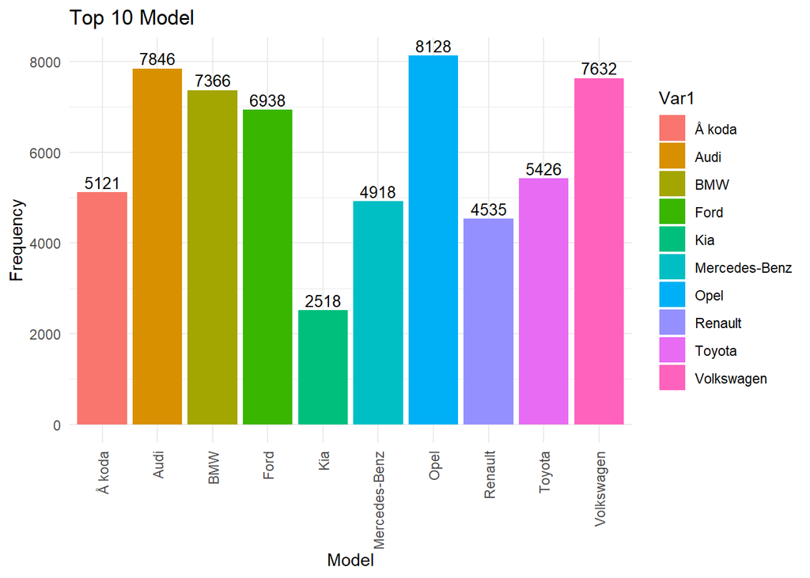

The data is left skewed where most of the cars produced in the year of between 2010 to 2020.

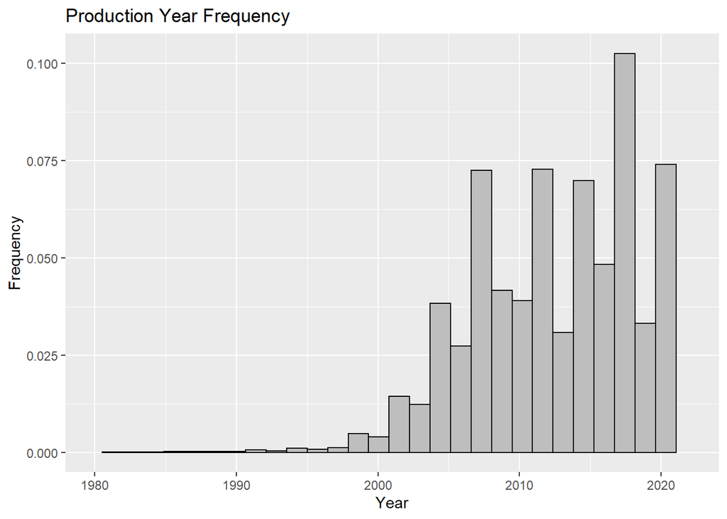

There is slightly positive relation between the Displacement and the Power HP.

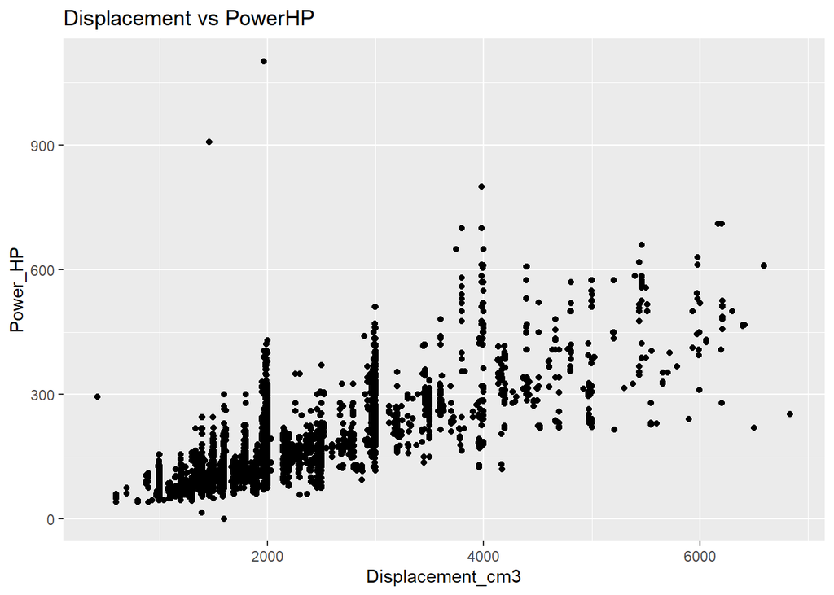

From the Below graph we can say that the Black color cars are most likely and most frequent as compares to others. Whereas the Yellow is least interested color in the cars.

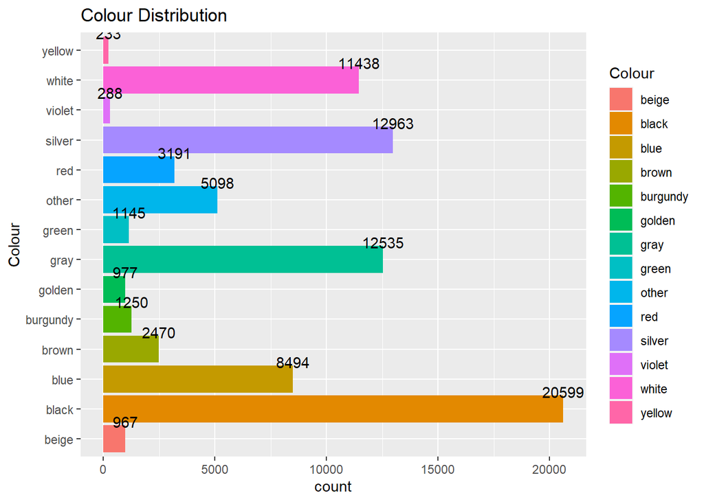

From the below graphs we could say that the there is no new Gasoline and CNG cars.

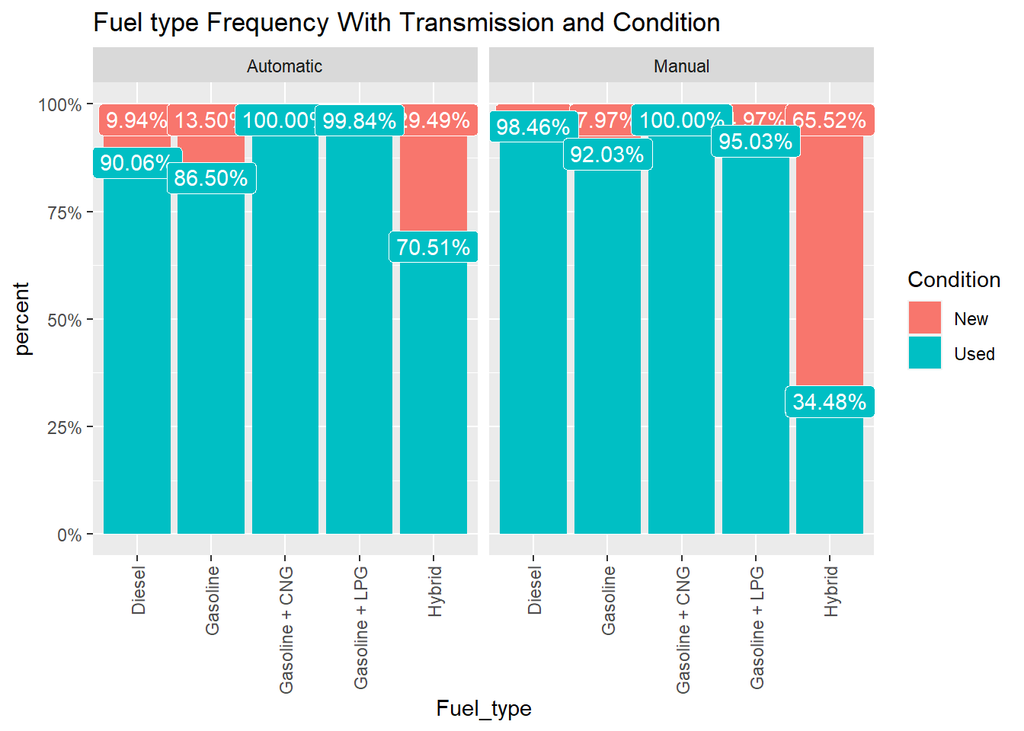

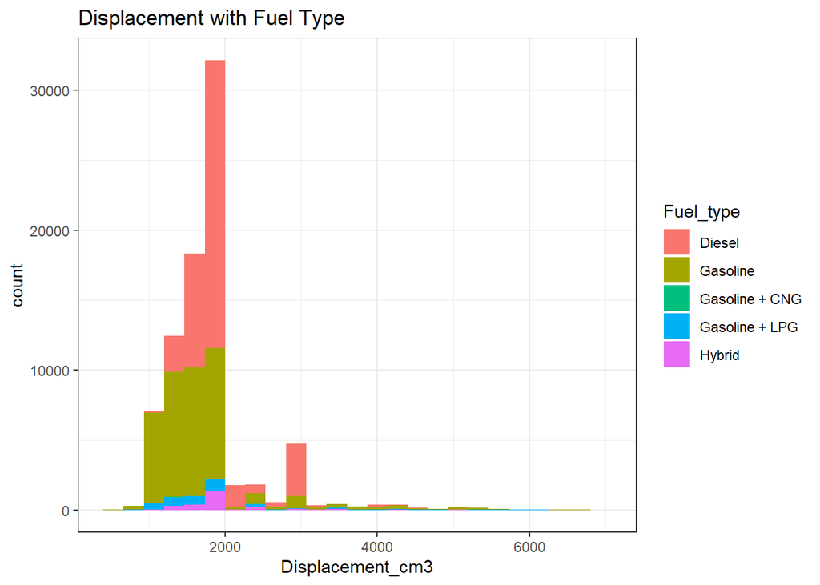

There are Most of the cars has Diesel and Gasoline Fuel type Where as Hybrid and

Gasoline cng and Gasoline LPG has least frequency.

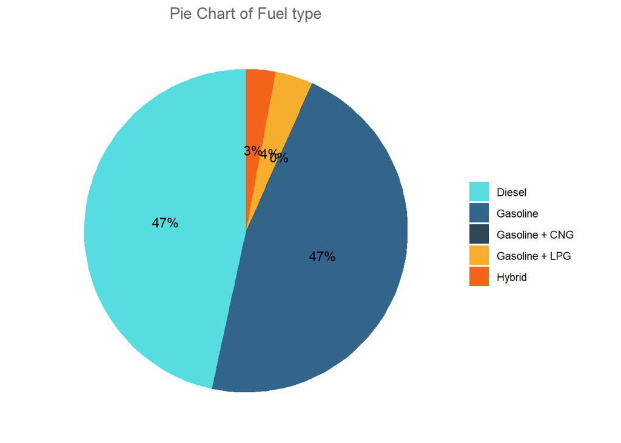

Here we could see the relation between the fuel type and Price as Hybrid has the

maximum average price and Gasoline LPG and Gasoline CNG has least average price.

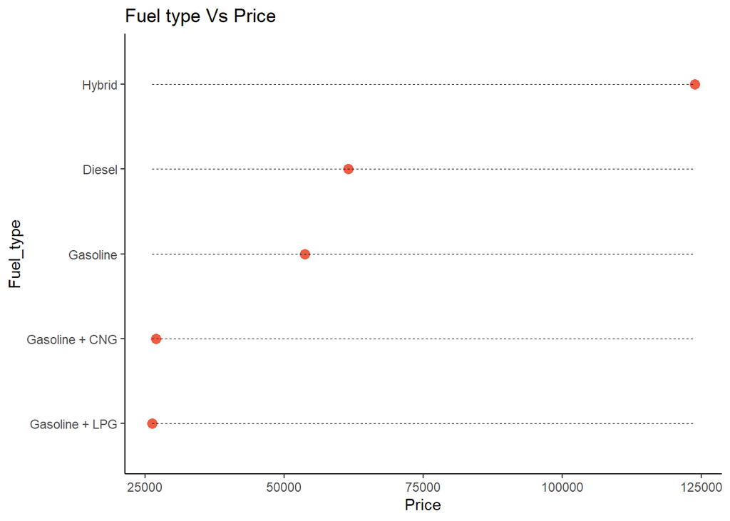

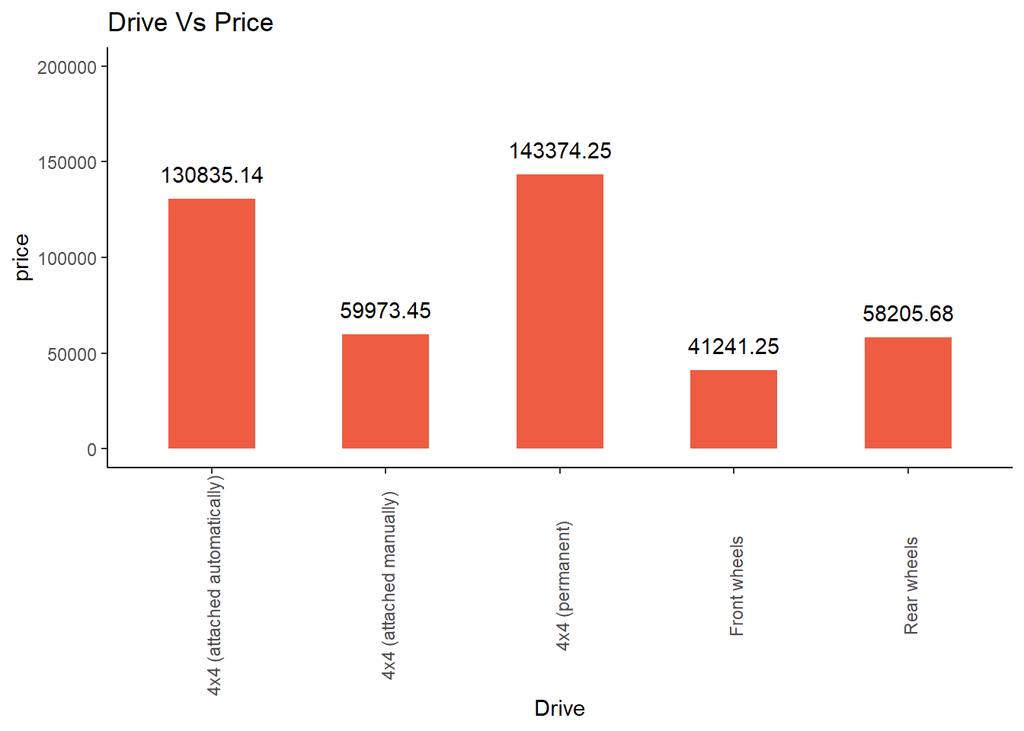

the Graph. Price is highle Skewed as compare to the Mileage Km.

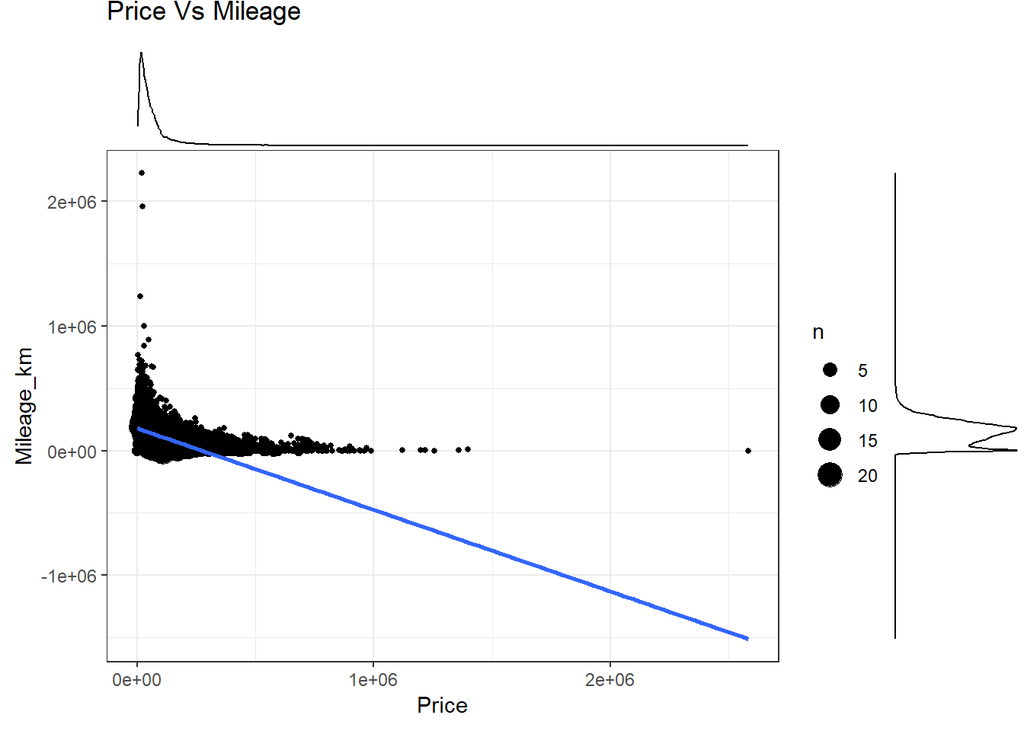

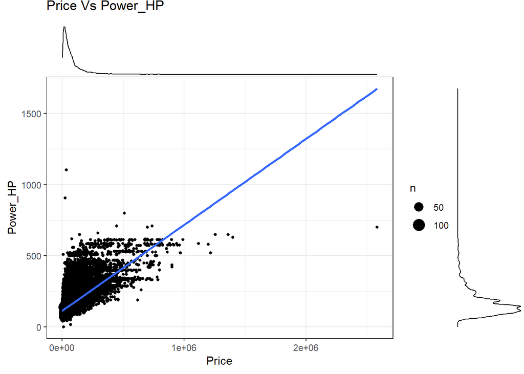

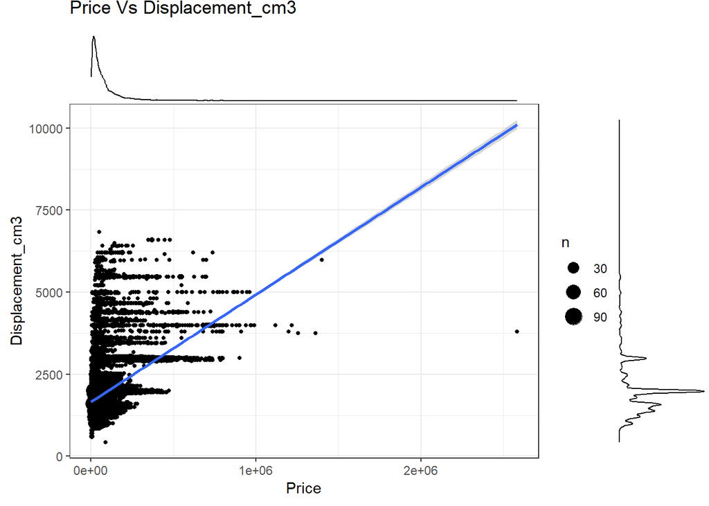

White colour Cars has the highest average price and black has 65922 average price. Silver has the least cost as 36550.

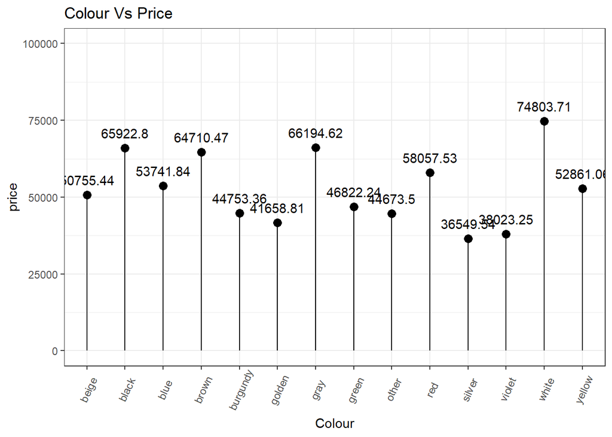

Coupe and SUV has the highest price and City cars and Small cars has the lowest price .

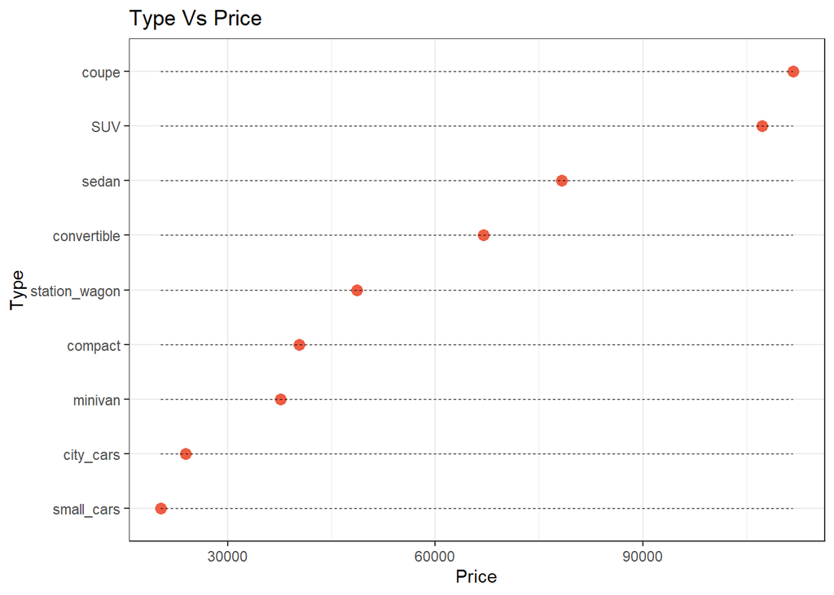

Most of the cars are belong to the Used category in the Condition category.

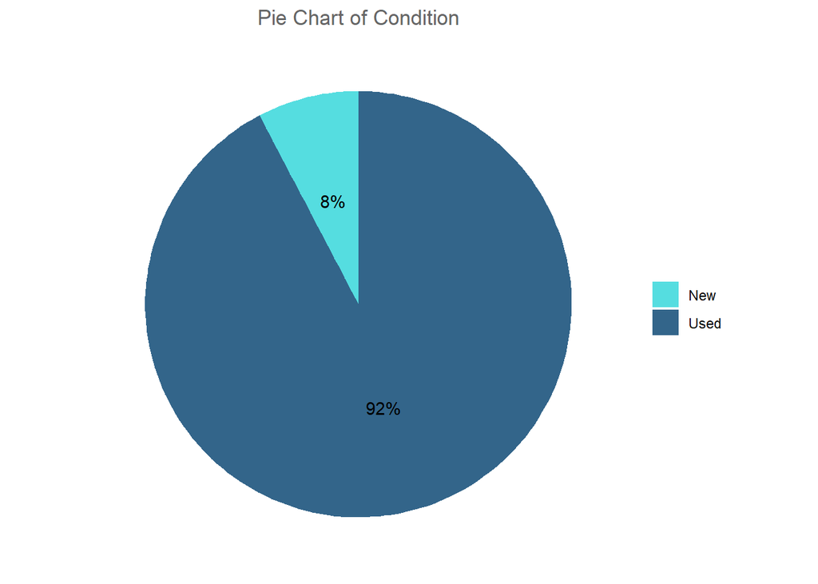

# Summary

As a result, we can say that in order to enter into polish car market, car industry companies should analyze average income of families in Poland and sell new cars with affordable prices which has no extremely better features compare to other cars.If we were a car company, based on results that we got we would produce small city cars mostly which has affordable price, and features also is not very low and from Polish population’s buying intentions also seemed that they do like mostly small city cars compare to jeeps.